# Effects of Music on Mood

May 9, 2016

The Effects of Music on Mood research project was conducted via Survey Monkey. Participants were first exposed to a short youtube music video clip of either negative, none, or positive music while viewing a list of 25 words presented one at a time. Next, participants were asked to rate their mood. Participants then answered 5 easy mathematical computations as a distractor task and then were asked to recall as many words as they could remember and provide some basic demographic information such as gender and age.

The following is the data collected from our Psy 441 Capstone Senior Project “Effects of Music on Mood”.

```r
dat<-read.csv("EffectsofMusiconMood.csv")
```

```r
str(dat)
```

```
## 'data.frame':    52 obs. of  3 variables:
##  $ Mood.Rating  : int  4 4 5 4 5 5 6 7 6 4 ...
##  $ Words.Correct: int  5 6 4 9 1 3 7 0 4 10 ...
##  $ Condition    : Factor w/ 3 levels "Neg","None","Pos": 3 3 1 2 2 3 1 1 1 2 ...
```

From looking at the structure of our data, we can see that there were a total of 52 participants and 3 variables: mood rating, Number of words recalled correct, and music condition (negative,none, or positive).

To analyze our data, we will conduct a one-way between subjects ANOVA examining for effects of Mood for condition and then create a line graph to help interpret the results.

```r
summary(aov(Mood.Rating~Condition, data=dat))
```

```
##             Df Sum Sq Mean Sq F value Pr(>F)
## Condition    2   7.02   3.511   1.737  0.187
## Residuals   49  99.04   2.021
```

According to the results of the ANOVA, the music condition had no effect on the participants mood rating, F(2,49) = 1.7, p = .187. Now let’s create our line graph to see how the music conditions affected mood. First we’ll need to load our graphics libraries.

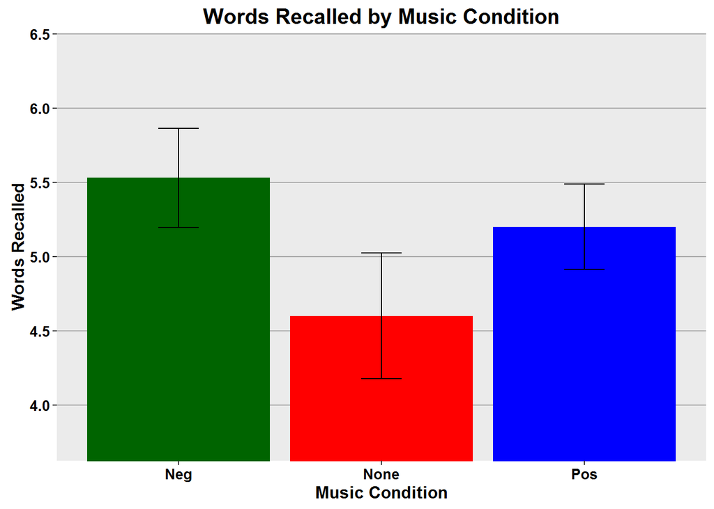

```r
library(ggplot2)
library(gplots)
library(dplyr)
temp<-dat%>%group_by(Condition)%>%
  summarize(means=mean(Mood.Rating),
            sems=sd(Mood.Rating)/sqrt(length(Mood.Rating)))

f<-ggplot(temp, aes(x=Condition,
                    y=means,
                    fill=Condition))+
  geom_bar(stat="identity",position=position_dodge())+
  scale_fill_manual(values=c("darkgreen","red","blue"),
                     name="Music",
                     breaks=c("neg","no", "pos"),
                     labels=c("Neg", "No", "Pos"))+
  geom_errorbar(aes(ymax=means+sems,
                    ymin=means-sems),
                width=.2,
                position=position_dodge(.9))+
  ggtitle("Words Recalled by Music Condition")+
  labs(x="Music Condition",y="Words Recalled")+
  theme(plot.title=element_text(size=15,face="bold",vjust=.5))+
  theme(axis.title.x=element_text(size=12,face="bold",vjust=-.25))+
  theme(axis.title.y=element_text(size=12,face="bold",vjust=1))+
  theme(axis.text.x=element_text(size=10,face="bold",color="black"))+
  theme(axis.text.y=element_text(size=10,face="bold",color="black"))+
  coord_cartesian(ylim=c(min(temp$means)-2*max(temp$sems),
                         max(temp$means)+2*max(temp$sems)))+
  theme(panel.border=element_blank(),axis.line=element_line())+
  theme(panel.grid.major.x=element_blank())+
  theme(panel.grid.major.y=element_line(color="darkgrey"))+
  theme(panel.grid.minor.y=element_blank())+
  theme(legend.position=c(.4,.76))+
  theme(legend.background=element_blank())+
  theme(legend.background=element_rect(color="black"))+
  theme(legend.title=element_blank())+
  theme(legend.title=element_text(size=12))+
  theme(legend.title.align=.5)+
  theme(legend.text=element_text(size=10,face="bold"))
f
```

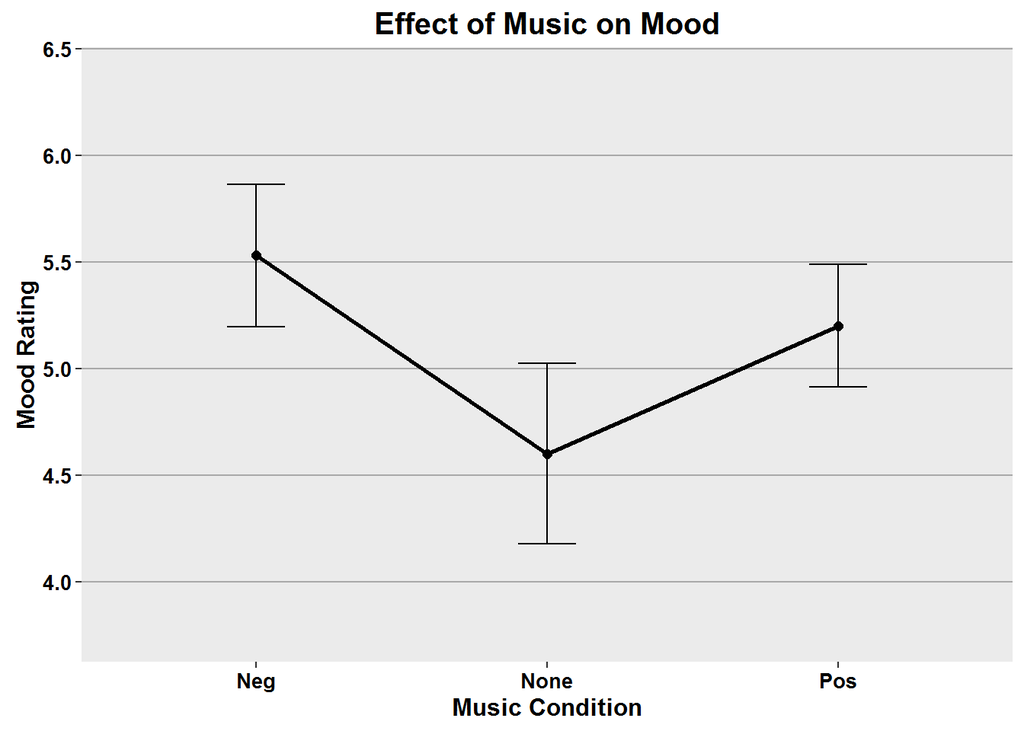

```r
f<-ggplot(temp, aes(x=as.factor(Condition),
                    y=means,
                    group=1))+
  geom_line(size=1)+
  geom_point(size=2)+
  geom_errorbar(aes(ymax=means+sems,
                    ymin=means-sems),
                width=.2)+
  ggtitle("Effect of Music on Mood")+
  labs(x="Music Condition",y="Mood Rating")+
  theme(plot.title=element_text(size=15,face="bold",vjust=.5))+
  theme(axis.title.x=element_text(size=12,face="bold",vjust=-.25))+
  theme(axis.title.y=element_text(size=12,face="bold",vjust=1))+
  theme(axis.text.x=element_text(size=10,face="bold",color="black"))+
  theme(axis.text.y=element_text(size=10,face="bold",color="black"))+
  coord_cartesian(ylim=c(min(temp$means)-2*max(temp$sems),
                         max(temp$means)+2*max(temp$sems)))+
  theme(panel.border=element_blank(),axis.line=element_line())+
  theme(panel.grid.major.x=element_blank())+
  theme(panel.grid.major.y=element_line(color="darkgrey"))+
  theme(panel.grid.minor.y=element_blank())
f
```

Next we will run another one-way between subjects ANOVA to examining for effects of Words Correct for condition and then create a second line graph to help interpret the results.

```r
summary(aov(Words.Correct~Condition, data=dat))
```

```
##             Df Sum Sq Mean Sq F value Pr(>F)
## Condition    2   72.8   36.40   3.209  0.049 *
## Residuals   49  555.9   11.34
## ---
## Signif. codes:  0 '***' 0.001 '**' 0.01 '*' 0.05 '.' 0.1 ' ' 1
```

Based on these results, we can also see that the music condition had an effect of the number of words recalled correctly, F(2,49) = 3.2, p = <.05.

Now lets creat a bar graph to help us interpret this analysis.

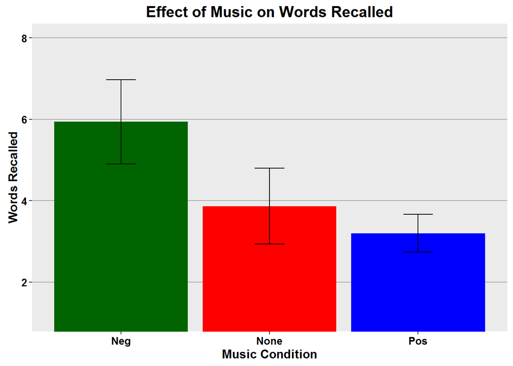

```r
library(ggplot2)
library(gplots)
library(dplyr)

temp<-dat%>%group_by(Condition)%>%
  summarize(means=mean(Words.Correct),
            sems=sd(Words.Correct)/sqrt(length(Words.Correct)))

f<-ggplot(temp, aes(x=Condition,
                    y=means,
                    fill=Condition))+
  geom_bar(stat="identity",position=position_dodge())+
  scale_fill_manual(values=c("darkgreen","red","blue"),
                     name="Music",
                     breaks=c("neg","no", "pos"),
                     labels=c("Neg", "No", "Pos"))+
  geom_errorbar(aes(ymax=means+sems,
                    ymin=means-sems),
                width=.2,
                position=position_dodge(.9))+
  ggtitle("Effect of Music on Words Recalled")+
  labs(x="Music Condition",y="Words Recalled")+
  theme(plot.title=element_text(size=15,face="bold",vjust=.5))+
  theme(axis.title.x=element_text(size=12,face="bold",vjust=-.25))+
  theme(axis.title.y=element_text(size=12,face="bold",vjust=1))+
  theme(axis.text.x=element_text(size=10,face="bold",color="black"))+
  theme(axis.text.y=element_text(size=10,face="bold",color="black"))+
  coord_cartesian(ylim=c(min(temp$means)-2*max(temp$sems),
                         max(temp$means)+2*max(temp$sems)))+
  theme(panel.border=element_blank(),axis.line=element_line())+
  theme(panel.grid.major.x=element_blank())+
  theme(panel.grid.major.y=element_line(color="darkgrey"))+
  theme(panel.grid.minor.y=element_blank())+
  theme(legend.position=c(.4,.76))+
  theme(legend.background=element_blank())+
  theme(legend.background=element_rect(color="black"))+
  theme(legend.title=element_blank())+
  theme(legend.title=element_text(size=12))+
  theme(legend.title.align=.5)+
  theme(legend.text=element_text(size=10,face="bold"))
f
```

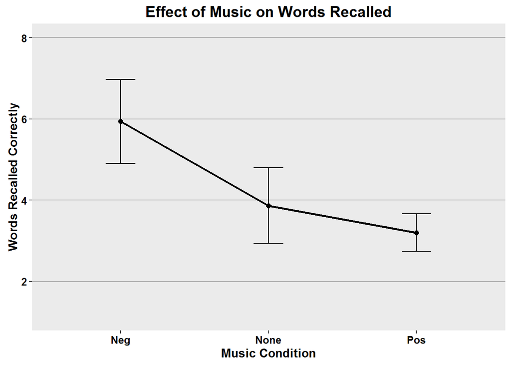

```r
f<-ggplot(temp, aes(x=as.factor(Condition),
                    y=means,
                    group=1))+
  geom_line(size=1)+
  geom_point(size=2)+
  geom_errorbar(aes(ymax=means+sems,
                    ymin=means-sems),
                width=.2)+
  ggtitle("Effect of Music on Words Recalled")+
  labs(x="Music Condition",y="Words Recalled Correctly")+
  theme(plot.title=element_text(size=15,face="bold",vjust=.5))+
  theme(axis.title.x=element_text(size=12,face="bold",vjust=-.25))+
  theme(axis.title.y=element_text(size=12,face="bold",vjust=1))+
  theme(axis.text.x=element_text(size=10,face="bold",color="black"))+
  theme(axis.text.y=element_text(size=10,face="bold",color="black"))+
  coord_cartesian(ylim=c(min(temp$means)-2*max(temp$sems),
                         max(temp$means)+2*max(temp$sems)))+
  theme(panel.border=element_blank(),axis.line=element_line())+
  theme(panel.grid.major.x=element_blank())+
  theme(panel.grid.major.y=element_line(color="darkgrey"))+
  theme(panel.grid.minor.y=element_blank())
f
```

Based on the results of this analysis, we can see that participants who heard negative music had the greatest number of words recalled correctly while participants who listened to the positive music had the lowest number of words recalled correctly.

```r
mean(dat$Words.Correct[dat$Condition=="Neg"])
```

```
## [1] 5.941176
```

```r
mean(dat$Words.Correct[dat$Condition=="Pos"])
```

```
## [1] 3.2
```

```r
mean(dat$Words.Correct[dat$Condition=="None"])
```

```
## [1] 3.866667
```

```r
t.test(dat$Words.Correct[dat$Condition=="None"],
dat$Words.Correct[dat$Condition=="Pos"],
var.equal=TRUE)
```

```
##
##  Two Sample t-test
##
## data:  dat$Words.Correct[dat$Condition == "None"] and dat$Words.Correct[dat$Condition == "Pos"]
## t = 0.68885, df = 33, p-value = 0.4957
## alternative hypothesis: true difference in means is not equal to 0
## 95 percent confidence interval:
##  -1.302333  2.635667
## sample estimates:
## mean of x mean of y
##  3.866667  3.200000
```

```r
t.test(dat$Words.Correct[dat$Condition=="None"],
dat$Words.Correct[dat$Condition=="Neg"],
var.equal=TRUE)
```

```
##
##  Two Sample t-test
##
## data:  dat$Words.Correct[dat$Condition == "None"] and dat$Words.Correct[dat$Condition == "Neg"]
## t = -1.4722, df = 30, p-value = 0.1514
## alternative hypothesis: true difference in means is not equal to 0
## 95 percent confidence interval:
##  -4.952279  0.803259
## sample estimates:
## mean of x mean of y
##  3.866667  5.941176
```

```r
t.test(dat$Words.Correct[dat$Condition=="Neg"],
dat$Words.Correct[dat$Condition=="Pos"],
var.equal=TRUE)
```

```
##
##  Two Sample t-test
##
## data:  dat$Words.Correct[dat$Condition == "Neg"] and dat$Words.Correct[dat$Condition == "Pos"]
## t = 2.5483, df = 35, p-value = 0.01537
## alternative hypothesis: true difference in means is not equal to 0
## 95 percent confidence interval:
##  0.5574393 4.9249137
## sample estimates:
## mean of x mean of y
##  5.941176  3.200000
```